# N-mixtures in mvgam

Nicholas J Clark

2025-03-14

The purpose of this vignette is to show how the `mvgam` package can be used to fit and interrogate N-mixture models for population abundance counts made with imperfect detection.

## N-mixture models

An N-mixture model is a fairly recent addition to the ecological modeller’s toolkit that is designed to make inferences about variation in the abundance of species when observations are imperfect ([Royle 2004](https://onlinelibrary.wiley.com/doi/10.1111/j.0006-341X.2004.00142.x)). Briefly, assume $\boldsymbol{Y_{i,r}}$ is the number of individuals recorded at site $i$ during replicate sampling observation $r$ (recorded as a non-negative integer). If multiple replicate surveys are done within a short enough period to satisfy the assumption that the population remained closed (i.e. there was no substantial change in true population size between replicate surveys), we can account for the fact that observations aren’t perfect. This is done by assuming that these replicate observations are Binomial random variables that are parameterized by the true “latent” abundance $N$ and a detection probability $p$:

$$\begin{align*}
\boldsymbol{Y_{i,r}} & \sim \text{Binomial}(N_i, p_r) \\
N_{i} & \sim \text{Poisson}(\lambda_i) \end{align*}$$

Using a set of linear predictors, we can estimate effects of covariates $\boldsymbol{X}$ on the expected latent abundance (with a log link for $\lambda$) and, jointly, effects of possibly different covariates (call them $\boldsymbol{Q}$) on detection probability (with a logit link for $p$):

$$\begin{align*}
log(\lambda) & = \beta \boldsymbol{X} \\
logit(p) & = \gamma \boldsymbol{Q}\end{align*}$$

`mvgam` can handle this type of model because it is designed to propagate unobserved temporal processes that evolve independently of the observation process in a State-space format. This setup adapts well to N-mixture models because they can be thought of as State-space models in which the latent state is a discrete variable representing the “true” but unknown population size. This is very convenient because we can incorporate any of the package’s diverse effect types (i.e. multidimensional splines, time-varying effects, monotonic effects, random effects etc…) into the linear predictors. All that is required for this to work is a marginalization trick that allows `Stan`’s sampling algorithms to handle discrete parameters (see more about how this method of “integrating out” discrete parameters works in [this nice blog post by Maxwell Joseph](https://mbjoseph.github.io/posts/2020-04-28-a-step-by-step-guide-to-marginalizing-over-discrete-parameters-for-ecologists-using-stan/)).

The family `nmix()` is used to set up N-mixture models in `mvgam`, but we still need to do a little bit of data wrangling to ensure the data are set up in the correct format (this is especially true when we have more than one replicate survey per time period). The most important aspects are: (1) how we set up the observation `series` and `trend_map` arguments to ensure replicate surveys are mapped to the correct latent abundance model and (2) the inclusion of a `cap` variable that defines the maximum possible integer value to use for each observation when estimating latent abundance. The two examples below give a reasonable overview of how this can be done.

## Example 1: a two-species system with nonlinear trends

First we will use a simple simulation in which multiple replicate observations are taken at each timepoint for two different species. The simulation produces observations at a single site over six years, with five replicate surveys per year. Each species is simulated to have different nonlinear temporal trends and different detection probabilities. For now, detection probability is fixed (i.e. it does not change over time or in association with any covariates). Notice that we add the `cap` variable, which does not need to be static, to define the maximum possible value that we think the latent abundance could be for each timepoint. This simply needs to be large enough that we get a reasonable idea of which latent N values are most likely, without adding too much computational cost:

```r
set.seed(999)
# Simulate observations for species 1, which shows a declining trend and 0.7 detection probability
data.frame(
  site = 1,
  # five replicates per year; six years
  replicate = rep(1:5, 6),
  time = sort(rep(1:6, 5)),
  species = "sp_1",
  # true abundance declines nonlinearly
  truth = c(
    rep(28, 5),
    rep(26, 5),
    rep(23, 5),
    rep(16, 5),
    rep(14, 5),
    rep(14, 5)
  ),
  # observations are taken with detection prob = 0.7
  obs = c(
    rbinom(5, 28, 0.7),
    rbinom(5, 26, 0.7),
    rbinom(5, 23, 0.7),
    rbinom(5, 15, 0.7),
    rbinom(5, 14, 0.7),
    rbinom(5, 14, 0.7)
  )
) %>%
  # add 'series' information, which is an identifier of site, replicate and species
  dplyr::mutate(
    series = paste0(
      "site_", site,
      "_", species,
      "_rep_", replicate
    ),
    time = as.numeric(time),
    # add a 'cap' variable that defines the maximum latent N to
    # marginalize over when estimating latent abundance; in other words
    # how large do we realistically think the true abundance could be?
    cap = 100
  ) %>%
  dplyr::select(-replicate) -> testdat

# Now add another species that has a different temporal trend and a smaller
# detection probability (0.45 for this species)
testdat <- testdat %>%
  dplyr::bind_rows(data.frame(
    site = 1,
    replicate = rep(1:5, 6),
    time = sort(rep(1:6, 5)),
    species = "sp_2",
    truth = c(
      rep(4, 5),
      rep(7, 5),
      rep(15, 5),
      rep(16, 5),
      rep(19, 5),
      rep(18, 5)
    ),
    obs = c(
      rbinom(5, 4, 0.45),
      rbinom(5, 7, 0.45),
      rbinom(5, 15, 0.45),
      rbinom(5, 16, 0.45),
      rbinom(5, 19, 0.45),
      rbinom(5, 18, 0.45)
    )
  ) %>%
    dplyr::mutate(
      series = paste0(
        "site_", site,
        "_", species,
        "_rep_", replicate
      ),
      time = as.numeric(time),
      cap = 50
    ) %>%
    dplyr::select(-replicate))
```

This data format isn’t too difficult to set up, but it does differ from the traditional multidimensional array setup that is commonly used for fitting N-mixture models in other software packages. Next we ensure that species and series IDs are included as factor variables, in case we’d like to allow certain effects to vary by species

```r
testdat$species <- factor(testdat$species,
  levels = unique(testdat$species)
)
testdat$series <- factor(testdat$series,
  levels = unique(testdat$series)
)
```

Preview the dataset to get an idea of how it is structured:

```r
dplyr::glimpse(testdat)
```

```
#> Rows: 60
#> Columns: 7
#> $ site    <dbl> 1, 1, 1, 1, 1, 1, 1, 1, 1, 1, 1, 1, 1, 1, 1, 1, 1, 1, 1, 1, 1,…
#> $ time    <dbl> 1, 1, 1, 1, 1, 2, 2, 2, 2, 2, 3, 3, 3, 3, 3, 4, 4, 4, 4, 4, 5,…
#> $ species <fct> sp_1, sp_1, sp_1, sp_1, sp_1, sp_1, sp_1, sp_1, sp_1, sp_1, sp…
#> $ truth   <dbl> 28, 28, 28, 28, 28, 26, 26, 26, 26, 26, 23, 23, 23, 23, 23, 16…
#> $ obs     <int> 20, 19, 23, 17, 18, 21, 18, 21, 19, 18, 17, 16, 20, 11, 19, 9,…
#> $ series  <fct> site_1_sp_1_rep_1, site_1_sp_1_rep_2, site_1_sp_1_rep_3, site_…
#> $ cap     <dbl> 100, 100, 100, 100, 100, 100, 100, 100, 100, 100, 100, 100, 10…
```

```r
head(testdat, 12)
```

```
#>    site time species truth obs            series cap
#> 1     1    1    sp_1    28  20 site_1_sp_1_rep_1 100
#> 2     1    1    sp_1    28  19 site_1_sp_1_rep_2 100
#> 3     1    1    sp_1    28  23 site_1_sp_1_rep_3 100
#> 4     1    1    sp_1    28  17 site_1_sp_1_rep_4 100
#> 5     1    1    sp_1    28  18 site_1_sp_1_rep_5 100
#> 6     1    2    sp_1    26  21 site_1_sp_1_rep_1 100
#> 7     1    2    sp_1    26  18 site_1_sp_1_rep_2 100
#> 8     1    2    sp_1    26  21 site_1_sp_1_rep_3 100
#> 9     1    2    sp_1    26  19 site_1_sp_1_rep_4 100
#> 10    1    2    sp_1    26  18 site_1_sp_1_rep_5 100
#> 11    1    3    sp_1    23  17 site_1_sp_1_rep_1 100
#> 12    1    3    sp_1    23  16 site_1_sp_1_rep_2 100
```

### Setting up the `trend_map`

Finally, we need to set up the `trend_map` object. This is crucial for allowing multiple observations to be linked to the same latent process model (see more information about this argument in the [Shared latent states vignette](https://nicholasjclark.github.io/mvgam/articles/shared_states.html)). In this case, the mapping operates by species and site to state that each set of replicate observations from the same time point should all share the exact same latent abundance model:

```r
testdat %>%
  # each unique combination of site*species is a separate process
  dplyr::mutate(trend = as.numeric(factor(paste0(site, species)))) %>%
  dplyr::select(trend, series) %>%
  dplyr::distinct() -> trend_map
trend_map
```

```
#>    trend            series
#> 1      1 site_1_sp_1_rep_1
#> 2      1 site_1_sp_1_rep_2
#> 3      1 site_1_sp_1_rep_3
#> 4      1 site_1_sp_1_rep_4
#> 5      1 site_1_sp_1_rep_5
#> 6      2 site_1_sp_2_rep_1
#> 7      2 site_1_sp_2_rep_2
#> 8      2 site_1_sp_2_rep_3
#> 9      2 site_1_sp_2_rep_4
#> 10     2 site_1_sp_2_rep_5
```

Notice how all of the replicates for species 1 in site 1 share the same process (i.e. the same `trend`). This will ensure that all replicates are Binomial draws of the same latent N.

### Modelling with the `nmix()` family

Now we are ready to fit a model using `mvgam()`. This model will allow each species to have different detection probabilities and different temporal trends. We will use `Cmdstan` as the backend, which by default will use Hamiltonian Monte Carlo for full Bayesian inference

```r
mod <- mvgam(
  # the observation formula sets up linear predictors for
  # detection probability on the logit scale
  formula = obs ~ species - 1,

  # the trend_formula sets up the linear predictors for
  # the latent abundance processes on the log scale
  trend_formula = ~ s(time, by = trend, k = 4) + species,

  # the trend_map takes care of the mapping
  trend_map = trend_map,

  # nmix() family and data
  family = nmix(),
  data = testdat,

  # priors can be set in the usual way
  priors = c(
    prior(std_normal(), class = b),
    prior(normal(1, 1.5), class = Intercept_trend)
  ),
  samples = 1000
)
```

View the automatically-generated `Stan` code to get a sense of how the marginalization over latent N works

```r
code(mod)
```

```
#> // Stan model code generated by package mvgam
#> data {
#>   int<lower=0> total_obs; // total number of observations
#>   int<lower=0> n; // number of timepoints per series
#>   int<lower=0> n_sp_trend; // number of trend smoothing parameters
#>   int<lower=0> n_lv; // number of dynamic factors
#>   int<lower=0> n_series; // number of series
#>   matrix[n_series, n_lv] Z; // matrix mapping series to latent states
#>   int<lower=0> num_basis; // total number of basis coefficients
#>   int<lower=0> num_basis_trend; // number of trend basis coefficients
#>   vector[num_basis_trend] zero_trend; // prior locations for trend basis coefficients
#>   matrix[total_obs, num_basis] X; // mgcv GAM design matrix
#>   matrix[n * n_lv, num_basis_trend] X_trend; // trend model design matrix
#>   array[n, n_series] int<lower=0> ytimes; // time-ordered matrix (which col in X belongs to each [time, series] observation?)
#>   array[n, n_lv] int ytimes_trend;
#>   int<lower=0> n_nonmissing; // number of nonmissing observations
#>   array[total_obs] int<lower=0> cap; // upper limits of latent abundances
#>   array[total_obs] int ytimes_array; // sorted ytimes
#>   array[n, n_series] int<lower=0> ytimes_pred; // time-ordered matrix for prediction
#>   int<lower=0> K_groups; // number of unique replicated observations
#>   int<lower=0> K_reps; // maximum number of replicate observations
#>   array[K_groups] int<lower=0> K_starts; // col of K_inds where each group starts
#>   array[K_groups] int<lower=0> K_stops; // col of K_inds where each group ends
#>   array[K_groups, K_reps] int<lower=0> K_inds; // indices of replicated observations
#>   matrix[3, 6] S_trend1; // mgcv smooth penalty matrix S_trend1
#>   matrix[3, 6] S_trend2; // mgcv smooth penalty matrix S_trend2
#>   array[total_obs] int<lower=0> flat_ys; // flattened observations
#> }
#> transformed data {
#>   matrix[total_obs, num_basis] X_ordered = X[ytimes_array,  : ];
#>   array[K_groups] int<lower=0> Y_max;
#>   array[K_groups] int<lower=0> N_max;
#>   for (k in 1 : K_groups) {
#>     Y_max[k] = max(flat_ys[K_inds[k, K_starts[k] : K_stops[k]]]);
#>     N_max[k] = max(cap[K_inds[k, K_starts[k] : K_stops[k]]]);
#>   }
#> }
#> parameters {
#>   // raw basis coefficients
#>   vector[num_basis] b_raw;
```

[output cut: 101 more lines]

```
#>         }
#>         prob_n = 1 + prob_n * ff * k_obs / N;
#>       }
#>
#>       // add log(pr_n) to prob(K_min)
#>       target += poisson_log_lpmf(K_min | log_lambda)
#>                 + binomial_logit_lpmf(N_obs | K_min, logit_p) + log(prob_n);
#>     }
#>   }
#> }
#> generated quantities {
#>   vector[n_lv] penalty = rep_vector(1e12, n_lv);
#>   vector[total_obs] detprob = inv_logit(p);
#>   vector[n_sp_trend] rho_trend = log(lambda_trend);
#> }
```

The posterior summary of this model shows that it has converged nicely

```r
summary(mod)
```

```
#> GAM observation formula:
#> obs ~ species - 1
#> <environment: 0x000002568cf5a610>
#>
#> GAM process formula:
#> ~s(time, by = trend, k = 4) + species
#> <environment: 0x000002568cf5a610>
#>
#> Family:
#> nmix
#>
#> Link function:
#> log
#>
#> Trend model:
#> None
#>
#> N process models:
#> 2
#>
#> N series:
#> 10
#>
#> N timepoints:
#> 6
#>
#> Status:
#> Fitted using Stan
#> 4 chains, each with iter = 1500; warmup = 500; thin = 1
#> Total post-warmup draws = 4000
#>
#>
#> GAM observation model coefficient (beta) estimates:
#>              2.5%   50% 97.5% Rhat n_eff
#> speciessp_1 -0.24 0.710   1.4    1  1502
#> speciessp_2 -1.20 0.011   0.9    1  1959
#>
#> GAM process model coefficient (beta) estimates:
#>                               2.5%     50%  97.5% Rhat n_eff
#> (Intercept)_trend            2.700  3.0000  3.400    1  1367
```

[output cut: 9 more lines]

```
#>                       edf Ref.df Chi.sq p-value
#> s(time):seriestrend1 1.03      3   1.67    0.77
#> s(time):seriestrend2 1.03      3   2.90    0.68
#>
#> Stan MCMC diagnostics:
#> ✔ No issues with effective samples per iteration
#> ✔ Rhat looks good for all parameters
#> ✔ No issues with divergences
#> ✔ No issues with maximum tree depth
#>
#> Samples were drawn using sampling(hmc). For each parameter, n_eff is a
#>   crude measure of effective sample size, and Rhat is the potential scale
#>   reduction factor on split MCMC chains (at convergence, Rhat = 1)
#>
#> Use how_to_cite() to get started describing this model
```

`loo()` functionality works just as it does for all `mvgam` models to aid in model comparison / selection (though note that Pareto K values often give warnings for mixture models so these may not be too helpful)

```r
loo(mod)
```

```
#>
#> Computed from 4000 by 60 log-likelihood matrix.
#>
#>          Estimate   SE
#> elpd_loo   -240.3 16.1
#> p_loo        93.5 15.3
#> looic       480.7 32.2
#> ------
#> MCSE of elpd_loo is NA.
#> MCSE and ESS estimates assume MCMC draws (r_eff in [0.4, 1.1]).
#>
#> Pareto k diagnostic values:
#>                          Count Pct.    Min. ESS
#> (-Inf, 0.7]   (good)     30    50.0%   641
#>    (0.7, 1]   (bad)       3     5.0%   <NA>
#>    (1, Inf)   (very bad) 27    45.0%   <NA>
#> See help('pareto-k-diagnostic') for details.
```

Plot the estimated smooths of time from each species’ latent abundance process (on the log scale)

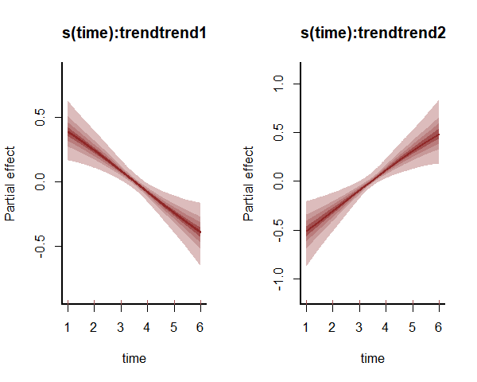

```r
plot(mod, type = "smooths", trend_effects = TRUE)
```

`marginaleffects` support allows for more useful prediction-based interrogations on different scales (though note that at the time of writing this Vignette, you must have the development version of `marginaleffects` installed for `nmix()` models to be supported; use `remotes::install_github('vincentarelbundock/marginaleffects')` to install). Objects that use family `nmix()` have a few additional prediction scales that can be used (i.e. `link`, `response`, `detection` or `latent_N`). For example, here are the estimated detection probabilities per species, which show that the model has done a nice job of estimating these parameters:

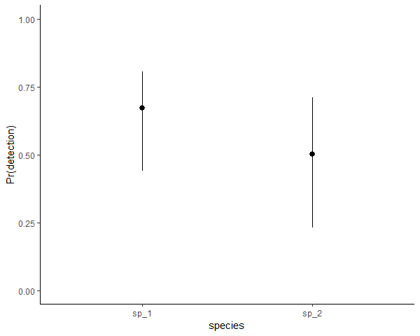

```r
marginaleffects::plot_predictions(mod,
  condition = "species",
  type = "detection"
) +
  ylab("Pr(detection)") +
  ylim(c(0, 1)) +
  theme_classic() +
  theme(legend.position = "none")
```

A common goal in N-mixture modelling is to estimate the true latent abundance. The model has automatically generated predictions for the unknown latent abundance that are conditional on the observations. We can extract these and produce decent plots using a small function

```r
hc <- hindcast(mod, type = "latent_N")

# Function to plot latent abundance estimates vs truth
plot_latentN <- function(hindcasts, data, species = "sp_1") {
  all_series <- unique(data %>%
    dplyr::filter(species == !!species) %>%
    dplyr::pull(series))

  # Grab the first replicate that represents this series
  # so we can get the true simulated values
  series <- as.numeric(all_series[1])
  truths <- data %>%
    dplyr::arrange(time, series) %>%
    dplyr::filter(series == !!levels(data$series)[series]) %>%
    dplyr::pull(truth)

  # In case some replicates have missing observations,
  # pull out predictions for ALL replicates and average over them
  hcs <- do.call(rbind, lapply(all_series, function(x) {
    ind <- which(names(hindcasts$hindcasts) %in% as.character(x))
    hindcasts$hindcasts[[ind]]
  }))

  # Calculate posterior empirical quantiles of predictions
  pred_quantiles <- data.frame(t(apply(hcs, 2, function(x) {
    quantile(x, probs = c(
      0.05, 0.2, 0.3, 0.4,
      0.5, 0.6, 0.7, 0.8, 0.95
    ))
  })))
  pred_quantiles$time <- 1:NROW(pred_quantiles)
  pred_quantiles$truth <- truths

  # Grab observations
  data %>%
    dplyr::filter(series %in% all_series) %>%
    dplyr::select(time, obs) -> observations

  # Plot
  ggplot(pred_quantiles, aes(x = time, group = 1)) +
    geom_ribbon(aes(ymin = X5., ymax = X95.), fill = "#DCBCBC") +
    geom_ribbon(aes(ymin = X30., ymax = X70.), fill = "#B97C7C") +
    geom_line(aes(x = time, y = truth),
      colour = "black", linewidth = 1
    ) +
    geom_point(aes(x = time, y = truth),
      shape = 21, colour = "white", fill = "black",
      size = 2.5
    ) +
    geom_jitter(
      data = observations, aes(x = time, y = obs),
      width = 0.06,
      shape = 21, fill = "darkred", colour = "white", size = 2.5
    ) +
    labs(
      y = "Latent abundance (N)",
      x = "Time",
      title = species
    )
}
```

Latent abundance plots vs the simulated truths for each species are shown below. Here, the red points show the imperfect observations, the black line shows the true latent abundance, and the ribbons show credible intervals of our estimates:

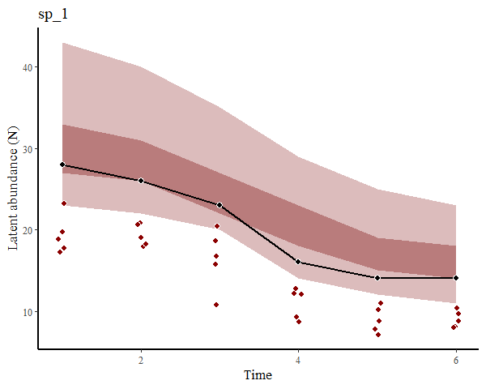

```r
plot_latentN(hc, testdat, species = "sp_1")
```

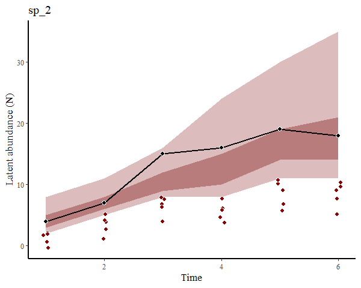

```r
plot_latentN(hc, testdat, species = "sp_2")
```

We can see that estimates for both species have correctly captured the true temporal variation and magnitudes in abundance

## Example 2: a larger survey with possible nonlinear effects

Now for another example with a larger dataset. We will use data from [Jeff Doser’s simulation example from the wonderful `spAbundance` package](https://doserlab.com/files/spabundance-web/articles/nmixturemodels). The simulated data include one continuous site-level covariate, one factor site-level covariate and two continuous sample-level covariates. This example will allow us to examine how we can include possibly nonlinear effects in the latent process and detection probability models.

Download the data and grab observations / covariate measurements for one species

```r
# Date link
load(url("https://github.com/doserjef/spAbundance/raw/main/data/dataNMixSim.rda"))
data.one.sp <- dataNMixSim

# Pull out observations for one species
data.one.sp$y <- data.one.sp$y[1, , ]

# Abundance covariates that don't change across repeat sampling observations
abund.cov <- dataNMixSim$abund.covs[, 1]
abund.factor <- as.factor(dataNMixSim$abund.covs[, 2])

# Detection covariates that can change across repeat sampling observations
# Note that `NA`s are not allowed for covariates in mvgam, so we randomly
# impute them here
det.cov <- dataNMixSim$det.covs$det.cov.1[, ]
det.cov[is.na(det.cov)] <- rnorm(length(which(is.na(det.cov))))
det.cov2 <- dataNMixSim$det.covs$det.cov.2
det.cov2[is.na(det.cov2)] <- rnorm(length(which(is.na(det.cov2))))
```

Next we wrangle into the appropriate ‘long’ data format, adding indicators of `time` and `series` for working in `mvgam`. We also add the `cap` variable to represent the maximum latent N to marginalize over for each observation

```r
mod_data <- do.call(
  rbind,
  lapply(1:NROW(data.one.sp$y), function(x) {
    data.frame(
      y = data.one.sp$y[x, ],
      abund_cov = abund.cov[x],
      abund_fac = abund.factor[x],
      det_cov = det.cov[x, ],
      det_cov2 = det.cov2[x, ],
      replicate = 1:NCOL(data.one.sp$y),
      site = paste0("site", x)
    )
  })
) %>%
  dplyr::mutate(
    species = "sp_1",
    series = as.factor(paste0(site, "_", species, "_", replicate))
  ) %>%
  dplyr::mutate(
    site = factor(site, levels = unique(site)),
    species = factor(species, levels = unique(species)),
    time = 1,
    cap = max(data.one.sp$y, na.rm = TRUE) + 20
  )
```

The data include observations for 225 sites with three replicates per site, though some observations are missing

```r
NROW(mod_data)
```

```
#> [1] 675
```

```r
dplyr::glimpse(mod_data)
```

```
#> Rows: 675
#> Columns: 11
#> $ y         <int> 1, NA, NA, NA, 2, 2, NA, 1, NA, NA, 0, 1, 0, 0, 0, 0, NA, NA…
#> $ abund_cov <dbl> -0.3734384, -0.3734384, -0.3734384, 0.7064305, 0.7064305, 0.…
#> $ abund_fac <fct> 3, 3, 3, 4, 4, 4, 9, 9, 9, 2, 2, 2, 3, 3, 3, 2, 2, 2, 1, 1, …
#> $ det_cov   <dbl> -1.28279990, 0.36376941, 0.01343699, 0.81359850, 0.19548086,…
#> $ det_cov2  <dbl> 2.03047314, 1.37976746, 0.44161953, -0.29263182, 1.04555361,…
#> $ replicate <int> 1, 2, 3, 1, 2, 3, 1, 2, 3, 1, 2, 3, 1, 2, 3, 1, 2, 3, 1, 2, …
#> $ site      <fct> site1, site1, site1, site2, site2, site2, site3, site3, site…
#> $ species   <fct> sp_1, sp_1, sp_1, sp_1, sp_1, sp_1, sp_1, sp_1, sp_1, sp_1, …
#> $ series    <fct> site1_sp_1_1, site1_sp_1_2, site1_sp_1_3, site2_sp_1_1, site…
#> $ time      <dbl> 1, 1, 1, 1, 1, 1, 1, 1, 1, 1, 1, 1, 1, 1, 1, 1, 1, 1, 1, 1, …
#> $ cap       <dbl> 33, 33, 33, 33, 33, 33, 33, 33, 33, 33, 33, 33, 33, 33, 33, …
```

```r
head(mod_data)
```

```
#>    y  abund_cov abund_fac     det_cov   det_cov2 replicate  site species
#> 1  1 -0.3734384         3 -1.28279990  2.0304731         1 site1    sp_1
#> 2 NA -0.3734384         3  0.36376941  1.3797675         2 site1    sp_1
#> 3 NA -0.3734384         3  0.01343699  0.4416195         3 site1    sp_1
#> 4 NA  0.7064305         4  0.81359850 -0.2926318         1 site2    sp_1
#> 5  2  0.7064305         4  0.19548086  1.0455536         2 site2    sp_1
#> 6  2  0.7064305         4  0.96730338  1.9197118         3 site2    sp_1
#>         series time cap
#> 1 site1_sp_1_1    1  33
#> 2 site1_sp_1_2    1  33
#> 3 site1_sp_1_3    1  33
#> 4 site2_sp_1_1    1  33
#> 5 site2_sp_1_2    1  33
#> 6 site2_sp_1_3    1  33
```

The final step for data preparation is of course the `trend_map`, which sets up the mapping between observation replicates and the latent abundance models. This is done in the same way as in the example above

```r
mod_data %>%
  # each unique combination of site*species is a separate process
  dplyr::mutate(trend = as.numeric(factor(paste0(site, species)))) %>%
  dplyr::select(trend, series) %>%
  dplyr::distinct() -> trend_map

trend_map %>%
  dplyr::arrange(trend) %>%
  head(12)
```

```
#>    trend         series
#> 1      1 site100_sp_1_1
#> 2      1 site100_sp_1_2
#> 3      1 site100_sp_1_3
#> 4      2 site101_sp_1_1
#> 5      2 site101_sp_1_2
#> 6      2 site101_sp_1_3
#> 7      3 site102_sp_1_1
#> 8      3 site102_sp_1_2
#> 9      3 site102_sp_1_3
#> 10     4 site103_sp_1_1
#> 11     4 site103_sp_1_2
#> 12     4 site103_sp_1_3
```

Now we are ready to fit a model using `mvgam()`. Here we will use penalized splines for each of the continuous covariate effects to detect possible nonlinear associations. We also showcase how `mvgam` can make use of the different approximation algorithms available in `Stan` by using the meanfield variational Bayes approximator (this reduces computation time from around 90 seconds to around 12 seconds for this example)

```r
mod <- mvgam(
  # effects of covariates on detection probability;
  # here we use penalized splines for both continuous covariates
  formula = y ~ s(det_cov, k = 4) + s(det_cov2, k = 4),

  # effects of the covariates on latent abundance;
  # here we use a penalized spline for the continuous covariate and
  # hierarchical intercepts for the factor covariate
  trend_formula = ~ s(abund_cov, k = 4) +
    s(abund_fac, bs = "re"),

  # link multiple observations to each site
  trend_map = trend_map,

  # nmix() family and supplied data
  family = nmix(),
  data = mod_data,

  # standard normal priors on key regression parameters
  priors = c(
    prior(std_normal(), class = "b"),
    prior(std_normal(), class = "Intercept"),
    prior(std_normal(), class = "Intercept_trend"),
    prior(std_normal(), class = "sigma_raw_trend")
  ),

  # use Stan's variational inference for quicker results
  algorithm = "meanfield",

  # no need to compute "series-level" residuals
  residuals = FALSE,
  samples = 1000
)
```

Inspect the model summary but don’t bother looking at estimates for all individual spline coefficients. Notice how we no longer receive information on convergence because we did not use MCMC sampling for this model

```r
summary(mod, include_betas = FALSE)
```

[output not shown]

Again we can make use of `marginaleffects` support for interrogating the model through targeted predictions. First, we can inspect the estimated average detection probability

```r
marginaleffects::avg_predictions(mod, type = "detection")
```

```
#>
#>  Estimate 2.5 % 97.5 %
#>     0.601 0.541  0.658
#>
#> Type:  detection
```

Next investigate estimated effects of covariates on latent abundance using the `conditional_effects()` function and specifying `type = 'link'`; this will return plots on the expectation scale

```r
abund_plots <- plot(
  conditional_effects(mod,
    type = "link",
    effects = c(
      "abund_cov",
      "abund_fac"
    )
  ),
  plot = FALSE
)
```

The effect of the continuous covariate on expected latent abundance

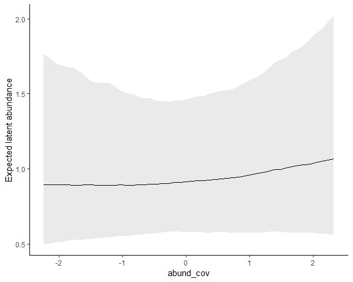

```r
abund_plots[[1]] +
  ylab("Expected latent abundance")
```

The effect of the factor covariate on expected latent abundance, estimated as a hierarchical random effect

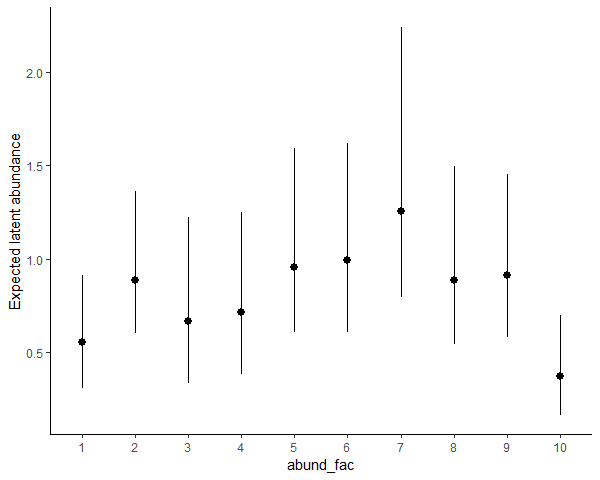

```r
abund_plots[[2]] +
  ylab("Expected latent abundance")
```

Now we can investigate estimated effects of covariates on detection probability using `type = 'detection'`

```r
det_plots <- plot(
  conditional_effects(mod,
    type = "detection",
    effects = c(
      "det_cov",
      "det_cov2"
    )
  ),
  plot = FALSE
)
```

The covariate smooths were estimated to be somewhat nonlinear on the logit scale according to the model summary (based on their approximate significances). But inspecting conditional effects of each covariate on the probability scale is more intuitive and useful

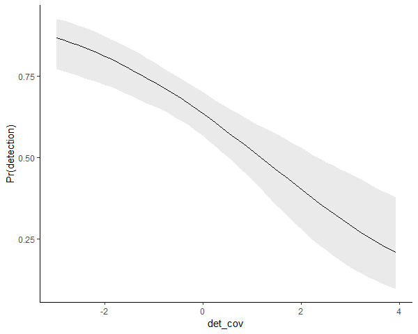

```r
det_plots[[1]] +
  ylab("Pr(detection)")
```

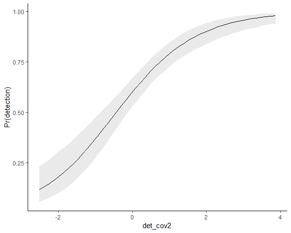

```r
det_plots[[2]] +
  ylab("Pr(detection)")
```

More targeted predictions are also easy with `marginaleffects` support. For example, we can ask: How does detection probability change as we change *both* detection covariates?

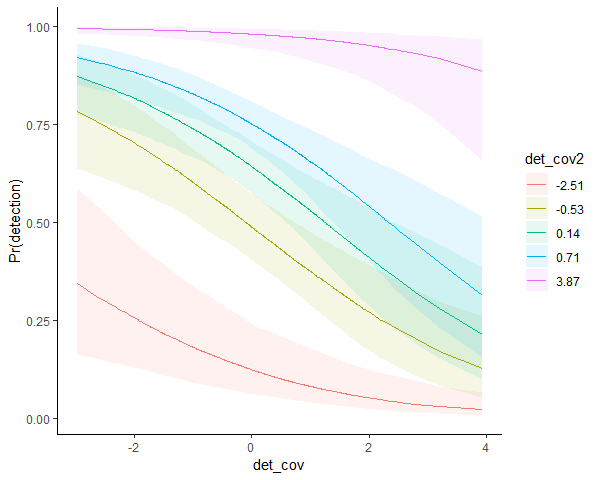

```r
fivenum_round <- function(x) round(fivenum(x, na.rm = TRUE), 2)

marginaleffects::plot_predictions(mod,
  newdata = marginaleffects::datagrid(
    det_cov = unique,
    det_cov2 = fivenum_round
  ),
  by = c("det_cov", "det_cov2"),
  type = "detection"
) +
  theme_classic() +
  ylab("Pr(detection)")
```

The model has found support for some important covariate effects, but of course we’d want to interrogate how well the model predicts and think about possible spatial effects to capture unmodelled variation in latent abundance (which can easily be incorporated into both linear predictors using spatial smooths).

## Further reading

The following papers and resources offer useful material about N-mixture models for ecological population dynamics investigations:

Guélat, Jérôme, and Kéry, Marc. “[Effects of Spatial Autocorrelation and Imperfect Detection on Species Distribution Models.](https://besjournals.onlinelibrary.wiley.com/doi/full/10.1111/2041-210X.12983)” *Methods in Ecology and Evolution* 9 (2018): 1614–25.

Kéry, Marc, and Royle Andrew J. “[Applied hierarchical modeling in ecology: Analysis of distribution, abundance and species richness in R and BUGS: Volume 2: Dynamic and advanced models](https://shop.elsevier.com/books/applied-hierarchical-modeling-in-ecology-analysis-of-distribution-abundance-and-species-richness-in-r-and-bugs/kery/978-0-12-809585-0)”. London, UK: Academic Press (2020).

Royle, Andrew J. “[N‐mixture models for estimating population size from spatially replicated counts.](https://onlinelibrary.wiley.com/doi/full/10.1111/j.0006-341X.2004.00142.x)” *Biometrics* 60.1 (2004): 108-115.

## Interested in contributing?

I’m actively seeking PhD students and other researchers to work in the areas of ecological forecasting, multivariate model evaluation and development of `mvgam`. Please see [this small list of opportunities on my website](https://ecogambler.netlify.app/opportunities/) and do reach out if you are interested (n.clark’at’uq.edu.au)